# CDA

Scott D Moore

May 14, 2016

# Basic R Training

### Session 1

### Agenda

- About: Scott_R
- Questions: Why are you here? What do you think you want to do with R ‘Work’, ‘Play’?
- Notes: rmarkdown will be made available; good, bad, and ugly:).

## Four things about R:

- VERY case sensitive.
- It is fun.
- Somebody has done it or at least thinking about it.
- Many ways to do it RIGHT.

## Today:

1. Work in ‘Chunks’.
2. Run ‘Swirl’.
3. Get you adjusted to R through self paced.
4. Familiar with some basics.
5. Goal: Be familiar enough so you can follow later presentations. You will not become an expert today.
6. Goal: Be able to navigate so you can start ‘producing’ today.

**Programming Topics**

- Basic Statistics.
- Data Frames.
- Subsetting.
- Grouping.
- Visualizations (histogram/boxplot/scatterplot/density estimates).
- Goal: Be able to analyze a small problem from data to visual.

# Swirl

See the docs here: http://swirlstats.com/students.html

Example:

```
# Install and load swirl
install.packages("swirl")
library(swirl)

# Install basic programming course
install_from_swirl("R_Programming")

# Run Swirl
swirl()
```

**“Goodmorning, Wells”**

# Programming Examples

R has it own data sets.

```r
data()
head(iris)
```

```
##   Sepal.Length Sepal.Width Petal.Length Petal.Width Species
## 1          5.1         3.5          1.4         0.2  setosa
## 2          4.9         3.0          1.4         0.2  setosa
## 3          4.7         3.2          1.3         0.2  setosa
## 4          4.6         3.1          1.5         0.2  setosa
## 5          5.0         3.6          1.4         0.2  setosa
## 6          5.4         3.9          1.7         0.4  setosa
```

### Loading New Data

Open a File. Set my Working Directory (Session) to where I want to find my data. ‘Pane’  
Read a file. csv is by the far the easist to open strongly recommend this file type for “us”. Remember the “”.

```r
cda <- read.csv("~/Downloads/Diabetes.csv", header = TRUE, sep = ",")
head(cda)
```

```
##     id chol glyhb age gender height weight  frame  bp waist
## 1 1000  203  4.31  46 female     62    121 medium 118    29
## 2 1001  165  4.44  29 female     64    218  large 112    46
## 3 1002  228  4.64  58 female     61    256  large 190    49
## 4 1003   78  4.63  67   male     67    119  large 110    33
## 5 1005  249  7.72  64   male     68    183 medium 138    44
## 6 1008  248  4.81  34   male     71    190  large 132    36
```

Alternative table output representations:

**Knitr**

```r
library(knitr)
knitr::kable(head(cda))
```

| id | chol | glyhb | age | gender | height | weight | frame | bp | waist |
| --- | --- | --- | --- | --- | --- | --- | --- | --- | --- |
| 1000 | 203 | 4.31 | 46 | female | 62 | 121 | medium | 118 | 29 |
| 1001 | 165 | 4.44 | 29 | female | 64 | 218 | large | 112 | 46 |
| 1002 | 228 | 4.64 | 58 | female | 61 | 256 | large | 190 | 49 |
| 1003 | 78 | 4.63 | 67 | male | 67 | 119 | large | 110 | 33 |
| 1005 | 249 | 7.72 | 64 | male | 68 | 183 | medium | 138 | 44 |
| 1008 | 248 | 4.81 | 34 | male | 71 | 190 | large | 132 | 36 |

**Datatable (aka DT)**

```r
library(DT)
DT::datatable(head(cda))
```

|  | id | chol | glyhb | age | gender | height | weight | frame | bp | waist |
| --- | --- | --- | --- | --- | --- | --- | --- | --- | --- | --- |
| 1 | 1000 | 203 | 4.309999943 | 46 | female | 62 | 121 | medium | 118 | 29 |
| 2 | 1001 | 165 | 4.440000057 | 29 | female | 64 | 218 | large | 112 | 46 |
| 3 | 1002 | 228 | 4.639999866 | 58 | female | 61 | 256 | large | 190 | 49 |
| 4 | 1003 | 78 | 4.630000114 | 67 | male | 67 | 119 | large | 110 | 33 |
| 5 | 1005 | 249 | 7.71999979 | 64 | male | 68 | 183 | medium | 138 | 44 |
| 6 | 1008 | 248 | 4.809999943 | 34 | male | 71 | 190 | large | 132 | 36 |

### Data Summaries and Metadata

Explore the data; object type (character vector), structure, basic statistics.

You can see what type any symbol is in R with the `class` function:

```r
class(cda)
```

```
## [1] "data.frame"
```

The `str` function will do its best to represent the structure of any object as a string, even complicated multi-dimensional ones with mixed data types:

```r
str(cda)
```

```
## 'data.frame':    403 obs. of  10 variables:
##  $ id    : int  1000 1001 1002 1003 1005 1008 1011 1015 1016 1022 ...
##  $ chol  : int  203 165 228 78 249 248 195 227 177 263 ...
##  $ glyhb : num  4.31 4.44 4.64 4.63 7.72 ...
##  $ age   : int  46 29 58 67 64 34 30 37 45 55 ...
##  $ gender: Factor w/ 2 levels "female","male": 1 1 1 2 2 2 2 2 2 1 ...
##  $ height: int  62 64 61 67 68 71 69 59 69 63 ...
##  $ weight: int  121 218 256 119 183 190 191 170 166 202 ...
##  $ frame : Factor w/ 4 levels "","large","medium",..: 3 2 2 2 3 2 3 3 2 4 ...
##  $ bp    : int  118 112 190 110 138 132 161 NA 160 108 ...
##  $ waist : int  29 46 49 33 44 36 46 34 34 45 ...
```

Descriptive statistics functions give a quick overview of columns in a data frame (e.g. `summary`):

```r
summary(cda)
```

```
##        id             chol           glyhb            age
##  Min.   : 1000   Min.   : 78.0   Min.   : 2.68   Min.   :19.00
##  1st Qu.: 4792   1st Qu.:179.0   1st Qu.: 4.38   1st Qu.:34.00
##  Median :15766   Median :204.0   Median : 4.84   Median :45.00
##  Mean   :15978   Mean   :207.8   Mean   : 5.59   Mean   :46.85
##  3rd Qu.:20336   3rd Qu.:230.0   3rd Qu.: 5.60   3rd Qu.:60.00
##  Max.   :41756   Max.   :443.0   Max.   :16.11   Max.   :92.00
##                  NA's   :1       NA's   :13
##     gender        height          weight         frame           bp
##  female:234   Min.   :52.00   Min.   : 99.0         : 12   Min.   : 90.0
##  male  :169   1st Qu.:63.00   1st Qu.:151.0   large :103   1st Qu.:121.2
##               Median :66.00   Median :172.5   medium:184   Median :136.0
##               Mean   :66.02   Mean   :177.6   small :104   Mean   :136.9
##               3rd Qu.:69.00   3rd Qu.:200.0                3rd Qu.:146.8
##               Max.   :76.00   Max.   :325.0                Max.   :250.0
##               NA's   :5       NA's   :1                    NA's   :5
##      waist
##  Min.   :26.0
##  1st Qu.:33.0
##  Median :37.0
##  Mean   :37.9
##  3rd Qu.:41.0
##  Max.   :56.0
##  NA's   :2
```

Other libraries have even more in-depth statistical summaries (e.g. `psych::describe`):

```r
library(psych)
describe(cda)
```

```
##         vars   n     mean       sd   median  trimmed     mad     min
## id         1 403 15978.31 11881.12 15766.00 14704.79 8176.54 1000.00
## chol       2 402   207.85    44.45   204.00   204.93   37.06   78.00
## glyhb      3 390     5.59     2.24     4.84     5.11    0.83    2.68
## age        4 403    46.85    16.31    45.00    46.22   19.27   19.00
## gender*    5 403     1.42     0.49     1.00     1.40    0.00    1.00
## height     6 398    66.02     3.92    66.00    65.98    4.45   52.00
## weight     7 402   177.59    40.34   172.50   174.81   37.81   99.00
## frame*     8 403     2.94     0.79     3.00     2.97    1.48    1.00
## bp         9 398   136.90    22.74   136.00   134.87   20.76   90.00
## waist     10 401    37.90     5.73    37.00    37.58    5.93   26.00
##              max    range  skew kurtosis     se
## id      41756.00 40756.00  0.81     0.06 591.84
## chol      443.00   365.00  0.92     2.54   2.22
## glyhb      16.11    13.43  2.23     4.98   0.11
## age        92.00    73.00  0.32    -0.67   0.81
## gender*     2.00     1.00  0.33    -1.90   0.02
## height     76.00    24.00  0.03    -0.21   0.20
## weight    325.00   226.00  0.72     0.67   2.01
## frame*      4.00     3.00 -0.25    -0.62   0.04
## bp        250.00   160.00  1.10     2.38   1.14
## waist      56.00    30.00  0.47    -0.17   0.29
```

```r
detach("package:psych", unload=TRUE)
```

### Subsetting Data

```r
cda.subset <- subset(cda, chol > 125 & weight > 200)
head(cda.subset)
```

```
##      id chol glyhb age gender height weight frame  bp waist
## 2  1001  165  4.44  29 female     64    218 large 112    46
## 3  1002  228  4.64  58 female     61    256 large 190    49
## 10 1022  263  5.78  55 female     63    202 small 108    45
## 22 1253  234  4.67  47   male     67    230 large 137    45
## 23 1254  203 12.74  38 female     69    288 large 136    48
## 27 1280  232  5.10  37   male     68    252 large 140    43
```

Verify that the subset is different from the original:

```r
paste('The original dataset had', nrow(cda), 'rows and the subset has only', nrow(cda.subset))
```

```
## [1] "The original dataset had 403 rows and the subset has only 96"
```

“Subsets” can also include “projections”, or selections of specific fields:

```r
cda.subset <- subset(cda, chol > 125 & weight > 200, select=c('chol', 'weight'))
head(cda.subset)
```

```
##    chol weight
## 2   165    218
## 3   228    256
## 10  263    202
## 22  234    230
## 23  203    288
## 27  232    252
```

### Aggregating Data

“Aggregating” can mean many things, but one simple example would be to group by one variable and create summaries of some kind for another:

```r
# Compute mean "glycosolated hemoglobin" for each gender
aggregate(list(glyhb=cda$glyhb),  by=list(gender=cda$gender), FUN=mean)
```

```
##   gender glyhb
## 1 female    NA
## 2   male    NA
```

That didn’t work because the variable `glyhb` contains NA values (see the summaries above). To ignore these NA values we can pass `na.rm=TRUE` to the aggregate function:

```r
aggregate(list(glyhb=cda$glyhb),  by=list(gender=cda$gender), FUN=mean, na.rm=T)
```

```
##   gender    glyhb
## 1 female 5.494342
## 2   male 5.724074
```

Alternatively, a slightly nicer form of syntax for this is:

```r
# Aggregation using R's "formula" operator
aggregate(glyhb ~ gender, cda, FUN=mean, na.action=na.omit)
```

```
##   gender    glyhb
## 1 female 5.494342
## 2   male 5.724074
```

### Visualizing Data

*Univariate Plots*

Create a Histogram:

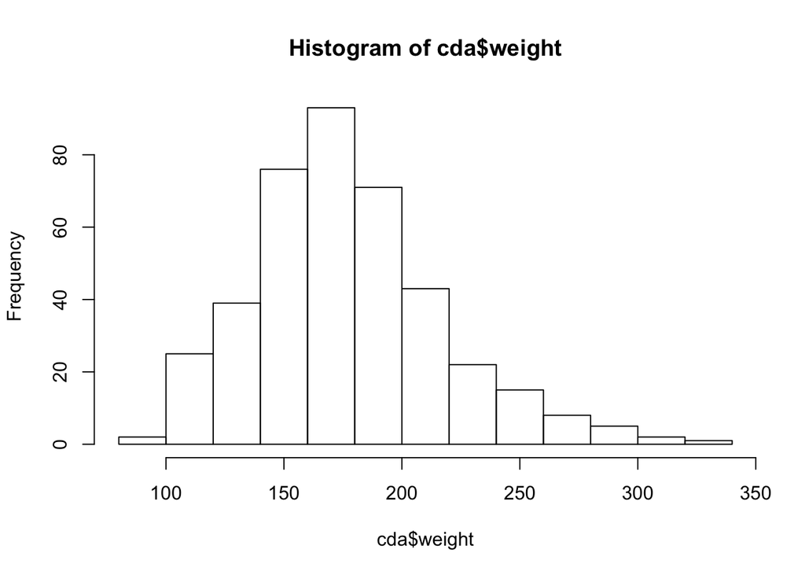

```r
hist(cda$weight)
```

Similarly, create a density estimate:

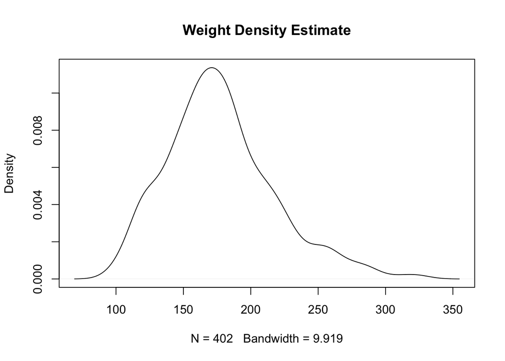

```r
plot(density(cda$weight, na.rm=T), main='Weight Density Estimate')
```

Create a Boxplot:

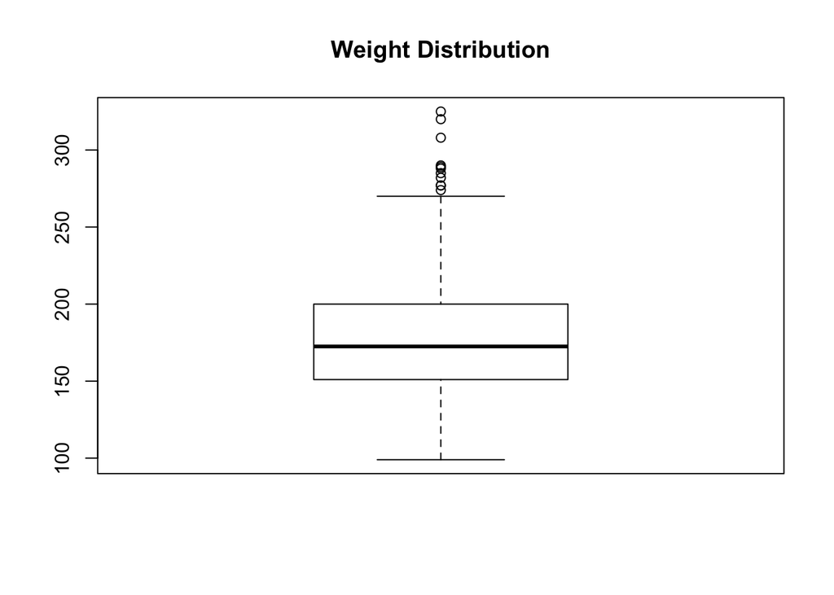

```r
boxplot(cda$weight, main='Weight Distribution')
```

*Multivariate Plots*

Create a Boxplot:

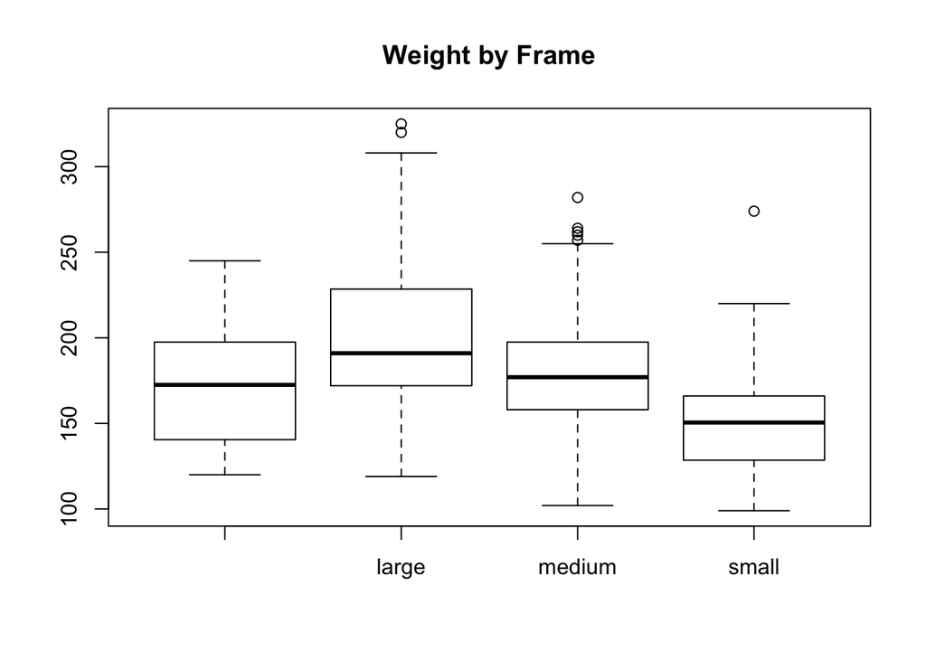

```r
boxplot(cda$weight ~ cda$frame, main='Weight by Frame')
```

Create a Scatterplot

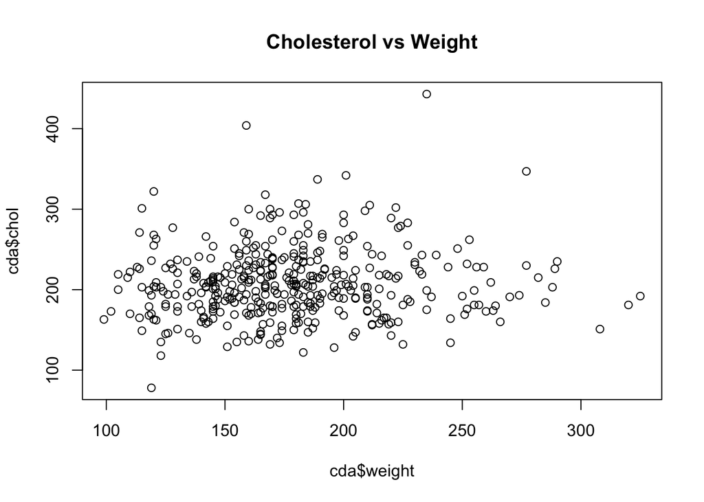

```r
plot(cda$weight, cda$chol, main='Cholesterol vs Weight')
```

# Summary

Your are now able to find your data, create basic statistics, manipulate data, display!

**Homework**: swirl - Basic R Programming.

Thank you. –S